# Исследование продаж компьютерных игр

Для интернет-магазина «Стримчик», занимающегося продажей компьютерых игр, анализируются определяющие успешность игры закономерности.

Данные за 36 лет (1980-2016гг) консолидированы из открытых источников о продажах игр, оценках пользователей и экспертов, жанрах и платформах.

Цель: планирование компании на 2017 год.

## Общая информация

```python
#импорт библиотек
import pandas as pd
import matplotlib.pyplot as plt
from scipy import stats as st
import numpy as np
import seaborn as sb
import warnings
```

```python
#чтение файла
try:
    data = pd.read_csv('/datasets/games.csv')
except:
    data = pd.read_csv('https://code.s3.yandex.net/datasets/games.csv')
```

```python
data.sample(10)#первые 10 строк
```

|  | Name | Platform | Year_of_Release | Genre | NA_sales | EU_sales | JP_sales | Other_sales | Critic_Score | User_Score | Rating |
| --- | --- | --- | --- | --- | --- | --- | --- | --- | --- | --- | --- |
| 3443 | MLB 11: The Show | PS3 | 2011.0 | Sports | 0.54 | 0.00 | 0.00 | 0.04 | 90.0 | 7.8 | E |
| 11843 | Big Mutha Truckers 2 | XB | 2005.0 | Racing | 0.05 | 0.02 | 0.00 | 0.00 | 50.0 | 3.4 | M |
| 15765 | The Cube | Wii | 2012.0 | Action | 0.00 | 0.02 | 0.00 | 0.00 | NaN | NaN | NaN |
| 6828 | Total War: Attila | PC | 2015.0 | Strategy | 0.09 | 0.13 | 0.00 | 0.02 | 80.0 | 7.3 | T |
| 10701 | Start the Party! Save the World | PS3 | 2011.0 | Misc | 0.00 | 0.08 | 0.00 | 0.02 | NaN | NaN | NaN |
| 16490 | Pippa Funnell 2: Farm Adventures | DS | 2007.0 | Simulation | 0.00 | 0.01 | 0.00 | 0.00 | NaN | NaN | NaN |
| 473 | NBA 2K13 | X360 | 2012.0 | Sports | 2.60 | 0.20 | 0.01 | 0.19 | 88.0 | 7.2 | E |
| 13722 | Shukufuku no Campanella Portable | PSP | 2010.0 | Adventure | 0.00 | 0.00 | 0.04 | 0.00 | NaN | NaN | NaN |
| 14311 | Zoo Tycoon | PC | 2001.0 | Strategy | 0.00 | 0.03 | 0.00 | 0.00 | NaN | NaN | NaN |
| 16144 | Penguins of Madagascar | Wii | 2014.0 | Action | 0.00 | 0.01 | 0.00 | 0.00 | NaN | tbd | E |

```python
data.info()#общая информация
```

```
<class 'pandas.core.frame.DataFrame'>
RangeIndex: 16715 entries, 0 to 16714
Data columns (total 11 columns):
 #   Column           Non-Null Count  Dtype
---  ------           --------------  -----
 0   Name             16713 non-null  object
 1   Platform         16715 non-null  object
 2   Year_of_Release  16446 non-null  float64
 3   Genre            16713 non-null  object
 4   NA_sales         16715 non-null  float64
 5   EU_sales         16715 non-null  float64
 6   JP_sales         16715 non-null  float64
 7   Other_sales      16715 non-null  float64
 8   Critic_Score     8137 non-null   float64
 9   User_Score       10014 non-null  object
 10  Rating           9949 non-null   object
dtypes: float64(6), object(5)
memory usage: 1.4+ MB
```

В датасете 11 столбцов с данными. Присутствуют только вещественный и строчный типы данных.

## Предобработка данных

```python
data.isna().sum()#просмотр пропусков
```

```
Name                  2
Platform              0
Year_of_Release     269
Genre                 2
NA_sales              0
EU_sales              0
JP_sales              0
Other_sales           0
Critic_Score       8578
User_Score         6701
Rating             6766
dtype: int64
```

```python
data.columns = data.columns.str.lower()#приведение названий столбцов к нижнем регистру
```

```python
def info_columns(data, column):#функция для обработки колонок
    data.boxplot(column)
    return data[column].describe()
```

Последовательно просмотрим все столбцы:

### Название игры

```python
data.loc[data['name'].isna()]# посмотрим на строки без названия игры
```

|  | name | platform | year_of_release | genre | na_sales | eu_sales | jp_sales | other_sales | critic_score | user_score | rating |
| --- | --- | --- | --- | --- | --- | --- | --- | --- | --- | --- | --- |
| 659 | NaN | GEN | 1993.0 | NaN | 1.78 | 0.53 | 0.00 | 0.08 | NaN | NaN | NaN |
| 14244 | NaN | GEN | 1993.0 | NaN | 0.00 | 0.00 | 0.03 | 0.00 | NaN | NaN | NaN |

```python
good_data = data.dropna(subset=['name']) # удалим строки с пропусками
```

Строчки без названия игры практически не содержат информации. Скорее всего, так как игры выпущены в 1993 году- данные в то время невозможно было собрать и их было легко потерять.

Также, удаляя эти строки, мы одновременно удаляем строки с пропусками в столбце "Жанр". Так как количество пропусков совпадает

### Платформа

```python
data['platform'].value_counts()# проверим неявные дубликаты
```

```
PS2     2161
DS      2151
PS3     1331
Wii     1320
X360    1262
PSP     1209
PS      1197
PC       974
XB       824
GBA      822
GC       556
3DS      520
PSV      430
PS4      392
N64      319
XOne     247
SNES     239
SAT      173
WiiU     147
2600     133
NES       98
GB        98
DC        52
GEN       29
NG        12
SCD        6
WS         6
3DO        3
TG16       2
GG         1
PCFX       1
Name: platform, dtype: int64
```

Похожие названия с одним смыслом, но разным типом написания отсутсвуют

### Год выпуска

```python
data.loc[data['year_of_release'].isna()]# посмотрим на строки без названия игры
```

|  | name | platform | year_of_release | genre | na_sales | eu_sales | jp_sales | other_sales | critic_score | user_score | rating |
| --- | --- | --- | --- | --- | --- | --- | --- | --- | --- | --- | --- |
| 183 | Madden NFL 2004 | PS2 | NaN | Sports | 4.26 | 0.26 | 0.01 | 0.71 | 94.0 | 8.5 | E |
| 377 | FIFA Soccer 2004 | PS2 | NaN | Sports | 0.59 | 2.36 | 0.04 | 0.51 | 84.0 | 6.4 | E |
| 456 | LEGO Batman: The Videogame | Wii | NaN | Action | 1.80 | 0.97 | 0.00 | 0.29 | 74.0 | 7.9 | E10+ |
| 475 | wwe Smackdown vs. Raw 2006 | PS2 | NaN | Fighting | 1.57 | 1.02 | 0.00 | 0.41 | NaN | NaN | NaN |
| 609 | Space Invaders | 2600 | NaN | Shooter | 2.36 | 0.14 | 0.00 | 0.03 | NaN | NaN | NaN |
| ... | ... | ... | ... | ... | ... | ... | ... | ... | ... | ... | ... |
| 16373 | PDC World Championship Darts 2008 | PSP | NaN | Sports | 0.01 | 0.00 | 0.00 | 0.00 | 43.0 | tbd | E10+ |
| 16405 | Freaky Flyers | GC | NaN | Racing | 0.01 | 0.00 | 0.00 | 0.00 | 69.0 | 6.5 | T |
| 16448 | Inversion | PC | NaN | Shooter | 0.01 | 0.00 | 0.00 | 0.00 | 59.0 | 6.7 | M |
| 16458 | Hakuouki: Shinsengumi Kitan | PS3 | NaN | Adventure | 0.01 | 0.00 | 0.00 | 0.00 | NaN | NaN | NaN |
| 16522 | Virtua Quest | GC | NaN | Role-Playing | 0.01 | 0.00 | 0.00 | 0.00 | 55.0 | 5.5 | T |

269 rows × 11 columns

```python
good_data = good_data.dropna(subset=['year_of_release'])# удаление пропусков
```

```python
good_data['year_of_release'] = good_data['year_of_release'].astype(int)# изменение типа
```

Количество строк без года выпуска (269) мало сравнительно со всем объемом, данные строки были удалены.

Тип данных был изменен на целочисленный, так как год не может быть вещественным числом.

### Жанр

```python
data['genre'].value_counts()# проверим неявные дубликаты
```

```
Action          3369
Sports          2348
Misc            1750
Role-Playing    1498
Shooter         1323
Adventure       1303
Racing          1249
Platform         888
Simulation       873
Fighting         849
Strategy         683
Puzzle           580
Name: genre, dtype: int64
```

Похожие названия с одним смыслом, но разным типом написания отсутсвуют

### Оценка пользователей

```python
good_data['user_score'] = data['user_score'].replace('tbd',np.nan).astype(float)# замена значений tbd на пропуски
```

'tbd' означает to be determned - будет определено. Такие значения заменим на пропуски.

```python
# посмотрим количество игр без оценки пользователей по годам
good_data[good_data['user_score'].isna()].pivot_table(columns='year_of_release',values='name', aggfunc='count')
```

| year_of_release | 1980 | 1981 | 1982 | 1983 | 1984 | 1985 | 1986 | 1987 | 1988 | 1989 | 1990 | 1991 | 1992 | 1993 | 1994 | 1995 | 1996 | 1997 | 1998 | 1999 | 2000 | 2001 | 2002 | 2003 | 2004 | 2005 | 2006 | 2007 | 2008 | … |
| --- | --- | --- | --- | --- | --- | --- | --- | --- | --- | --- | --- | --- | --- | --- | --- | --- | --- | --- | --- | --- | --- | --- | --- | --- | --- | --- | --- | --- | --- | --- |
| name | 9 | 46 | 36 | 17 | 14 | 13 | 21 | 16 | 14 | 17 | 16 | 41 | 42 | 60 | 120 | 219 | 255 | 271 | 348 | 307 | 243 | 225 | 365 | 259 | 273 | 356 | 454 | 568 | 766 | … |

Пропуски в столбце оценка пользователей не влияют на дальнеший анализ, и могли возникнуть, так как игры еще просто не оценены.

Также нельзя утверждать, что отсутсвует оценка только у давноизданных игр. В связи с тем, что такие игры есть в любом году.

### Рейтинг

```python
# сводная таблица: количество игр в каждом жанре
games_by_genre = good_data.pivot_table(index= 'rating',columns ='genre', values ='name', aggfunc='count')
games_by_genre
```

| genre rating | Action | Adventure | Fighting | Misc | Platform | Puzzle | Racing | Role-Playing | Shooter | Simulation | Sports | Strategy |
| --- | --- | --- | --- | --- | --- | --- | --- | --- | --- | --- | --- | --- |
| AO | 1.0 | NaN | NaN | NaN | NaN | NaN | NaN | NaN | NaN | NaN | NaN | NaN |
| E | 410.0 | 159.0 | 8.0 | 449.0 | 354.0 | 284.0 | 576.0 | 83.0 | 47.0 | 321.0 | 1162.0 | 68.0 |
| E10+ | 468.0 | 67.0 | 19.0 | 166.0 | 141.0 | 42.0 | 95.0 | 111.0 | 56.0 | 47.0 | 105.0 | 76.0 |
| EC | 1.0 | 2.0 | NaN | 5.0 | NaN | NaN | NaN | NaN | NaN | NaN | NaN | NaN |
| K-A | NaN | NaN | NaN | 1.0 | NaN | NaN | NaN | NaN | NaN | NaN | NaN | 2.0 |
| M | 596.0 | 98.0 | 48.0 | 13.0 | 3.0 | NaN | 18.0 | 161.0 | 553.0 | 5.0 | 16.0 | 25.0 |
| RP | NaN | NaN | NaN | NaN | NaN | NaN | NaN | NaN | NaN | NaN | NaN | 1.0 |
| T | 670.0 | 114.0 | 357.0 | 228.0 | 63.0 | 10.0 | 167.0 | 415.0 | 340.0 | 186.0 | 195.0 | 160.0 |

```python
good_data['rating'] = data['rating'].fillna('RP')# заполним пропуски
```

Rating Pending (RP)- означает, что рейтинг еще не был определен. В связи с этим, заменили пропуски на эту категорию.

Изначально в этой категории присутствовала всего одна игра.

### Продажи в Северной Америке

```
count    16715.000000
mean         0.263377
std          0.813604
min          0.000000
25%          0.000000
50%          0.080000
75%          0.240000
max         41.360000
Name: na_sales, dtype: float64
```

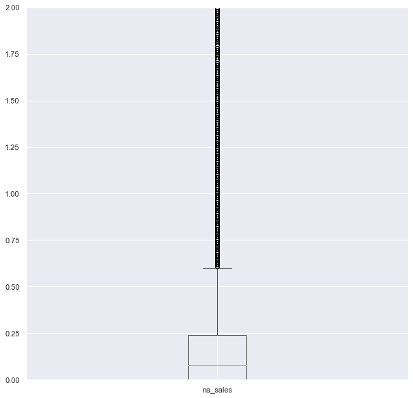

```python
plt.ylim(0,2)
info_columns(data, 'na_sales')# обработка столбца
```

### Продажи в Европе

```
count    16715.000000
mean         0.145060
std          0.503339
min          0.000000
25%          0.000000
50%          0.020000
75%          0.110000
max         28.960000
Name: eu_sales, dtype: float64
```

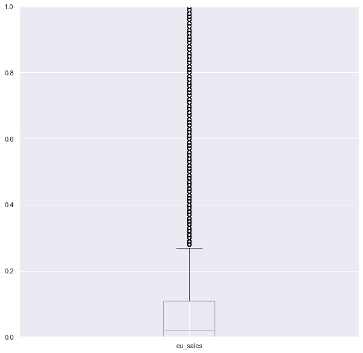

```python
plt.ylim(0,1)
info_columns(data, 'eu_sales')# обработка столбца
```

### Продажи в Японии

```
count    16715.000000
mean         0.077617
std          0.308853
min          0.000000
25%          0.000000
50%          0.000000
75%          0.040000
max         10.220000
Name: jp_sales, dtype: float64
```

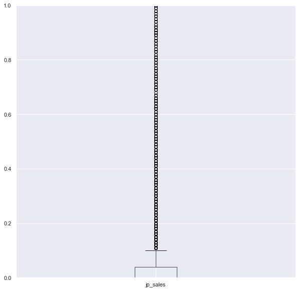

```python
plt.ylim(0,1)
info_columns(data, 'jp_sales')# обработка столбца
```

### Продажи в других странах

```
count    16715.000000
mean         0.047342
std          0.186731
min          0.000000
25%          0.000000
50%          0.010000
75%          0.030000
max         10.570000
Name: other_sales, dtype: float64
```

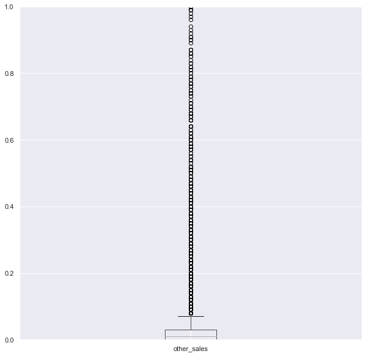

```python
plt.ylim(0,1)
info_columns(data, 'other_sales')# обработка столбца
```

### Оценка критиков

```
count    8137.000000
mean       68.967679
std        13.938165
min        13.000000
25%        60.000000
50%        71.000000
75%        79.000000
max        98.000000
Name: critic_score, dtype: float64
```

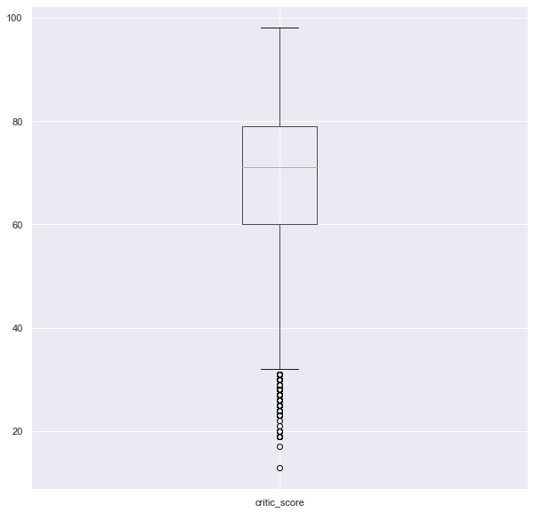

```python
info_columns(data, 'critic_score')# обработка столбца
```

Были просмотрены все столбцы с числовыми типами. Так продажи могут быть сколько угодно большими или малыми, выбросы были оставлены. Пропуски в столбце: "Оценка критиков" также были оставлены в связи с тем, что игра еще может быть не оценена.

```python
good_data[good_data.duplicated(subset=["name", "platform", "year_of_release"])]# поиск дубликатов
```

|  | name | platform | year_of_release | genre | na_sales | eu_sales | jp_sales | other_sales | critic_score | user_score | rating |
| --- | --- | --- | --- | --- | --- | --- | --- | --- | --- | --- | --- |
| 16230 | Madden NFL 13 | PS3 | 2012 | Sports | 0.0 | 0.01 | 0.0 | 0.0 | 83.0 | 5.5 | E |

```python
good_data = good_data.drop_duplicates().reset_index(drop=True)# удаление дубликатов
```

```python
# новый столбец с суммарными продажами
good_data['sum_sales'] = good_data['eu_sales'] + good_data['na_sales'] + good_data['jp_sales']+good_data['other_sales']
```

```python
round((data.shape[0]-good_data.shape[0])*100/data.shape[0],2)# процент удаленных строк
```

```
1.62
```

Были проанализированы все столбцы. Итого было удалено 2% исходных данных. Изменены типы данных для столбцов год выпуска и оценка пользователей на целочисленный и вещественный соответственно.

## Исследовательский анализ данных

### Количество игр, выпущенных в разные годы

```python
# сводная таблица: количество выпущенных игр по годам
games_by_year = good_data.pivot_table(columns = 'year_of_release', values = 'name',aggfunc ='count')
pd.set_option('display.max_columns', None)
games_by_year
```

| year_of_release | 1980 | 1981 | 1982 | 1983 | 1984 | 1985 | 1986 | 1987 | 1988 | 1989 | 1990 | 1991 | 1992 | 1993 | 1994 | 1995 | 1996 | 1997 | 1998 | 1999 | 2000 | 2001 | 2002 | 2003 | 2004 | 2005 | 2006 | 2007 | 2008 | … |
| --- | --- | --- | --- | --- | --- | --- | --- | --- | --- | --- | --- | --- | --- | --- | --- | --- | --- | --- | --- | --- | --- | --- | --- | --- | --- | --- | --- | --- | --- | --- |
| name | 9 | 46 | 36 | 17 | 14 | 14 | 21 | 16 | 15 | 17 | 16 | 41 | 43 | 60 | 121 | 219 | 263 | 289 | 379 | 338 | 350 | 482 | 829 | 775 | 762 | 939 | 1006 | 1197 | 1427 | … |

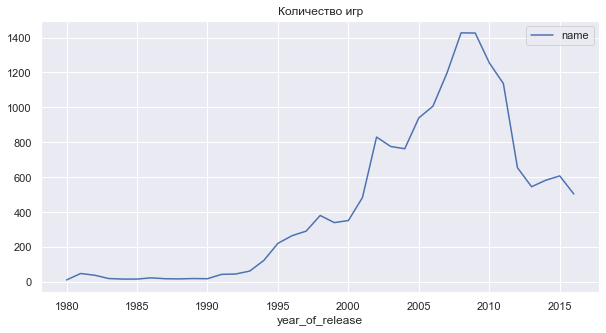

```python
# график:количество выпущенных игр по годам
games_by_year.transpose().plot(grid=True, title='Количество игр', figsize=(10,5));
```

Максимальный пик по выходу игр на рынок пришелся на 2005- 2011 года. Далее начали развиваться операционные системы iOS и Android, акцент сместился на создание игр для мобильных устройств.

### Продажи по платформам

```python
# сводная таблица: продажи по платформам
sales_by_platform = good_data.pivot_table(index = 'platform',values='sum_sales', aggfunc='sum')\
.sort_values(by='sum_sales', ascending=False).reset_index()
sales_by_platform = sales_by_platform.head(6)
list_platform = sales_by_platform['platform'].tolist()# создание листа с топ 6 платформами
sales_by_platform
```

|  | platform | sum_sales |
| --- | --- | --- |
| 0 | PS2 | 1233.56 |
| 1 | X360 | 961.24 |
| 2 | PS3 | 931.34 |
| 3 | Wii | 891.18 |
| 4 | DS | 802.78 |
| 5 | PS | 727.58 |

По глобальным продажам 6 платформ выбились в явные лидеры. Самое большое количество продаж у платформы PS2.

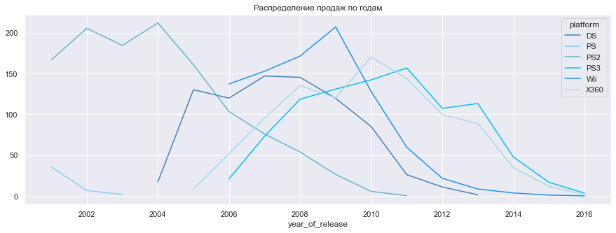

```python
# график:распределние продаж топ6 платформ по годам
good_data.query('(platform in @list_platform) and (year_of_release>2000)')\
.pivot_table(index = 'year_of_release',columns = 'platform', values = 'sum_sales', aggfunc='sum')\
.plot(figsize=(15,5), grid=True, title = 'Распределение продаж по годам', \
      color=['steelblue','lightskyblue','c','deepskyblue','dodgerblue','lightblue']);
```

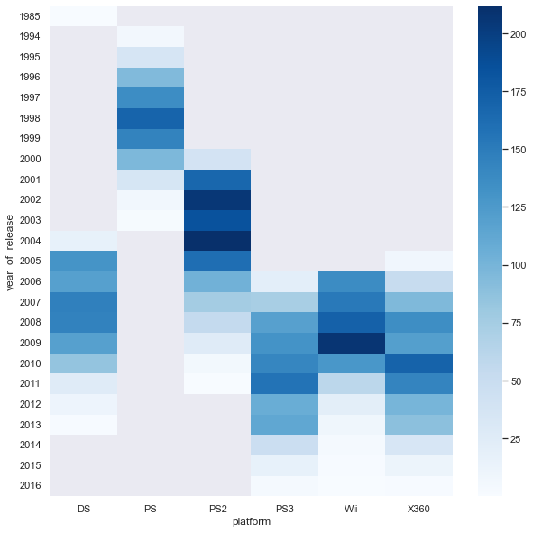

```python
# проверка среднего жизненного цикла
average_time = good_data.query('platform in @list_platform')\
.pivot_table(index = 'year_of_release', columns = 'platform', values = 'sum_sales', aggfunc='sum')
sb.set(rc = {'figure.figsize':(10,10)})
sb.heatmap(average_time,cmap= 'Blues');
```

Согласно графикам в среднем платформы существуют 10 лет. Также подтверждается, что с 2005 по 2011 года пришелся расцвет этого рынка. Наибольшее количество платформ присутствовали на рынке одновременно

Поскольку, начиная с 2012 года среднее количество вышедших игр держится в рамках 500-600, и данная отрасль является очень динамично изменяющейся, в качестве актуального периода примем 5 лет: 2012-2016.

### Продажи по платформам в актуальном периоде

```python
# продажи платформ в актуальном периоде
good_data_actual = good_data.query('(year_of_release>2011) and (year_of_release<=2016)')
```

```python
# сводная таблица:суммарные продажи платформ в актуальном периоде
sum_actual_sales = good_data_actual.pivot_table(columns = 'platform', values = 'sum_sales', aggfunc='sum')
sum_actual_sales
```

| platform | 3DS | DS | PC | PS3 | PS4 | PSP | PSV | Wii | WiiU | X360 | XOne |
| --- | --- | --- | --- | --- | --- | --- | --- | --- | --- | --- | --- |
| sum_sales | 194.61 | 12.55 | 62.65 | 288.79 | 314.14 | 11.19 | 49.18 | 35.37 | 82.19 | 236.54 | 159.32 |

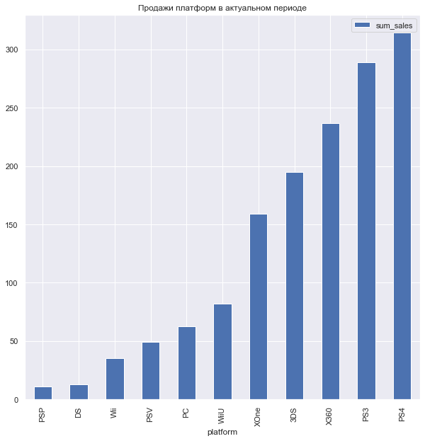

```python
# график с сортировкой по суммарным продажам
sum_actual_sales.T.sort_values(by='sum_sales')\
. plot(grid=True, title = 'Продажи платформ в актуальном периоде', kind= 'bar', legend=True);
```

```python
# сводная таблица:продажи платформ в актуальном периоде
sales_in_actual = good_data_actual\
.pivot_table(index = 'year_of_release',columns = 'platform', values = 'sum_sales', aggfunc='sum')
sales_in_actual
```

| platform year_of_release | 3DS | DS | PC | PS3 | PS4 | PSP | PSV | Wii | WiiU | X360 | XOne |
| --- | --- | --- | --- | --- | --- | --- | --- | --- | --- | --- | --- |
| 2012 | 51.36 | 11.01 | 23.22 | 107.36 | NaN | 7.69 | 16.19 | 21.71 | 17.56 | 99.74 | NaN |
| 2013 | 56.57 | 1.54 | 12.38 | 113.25 | 25.99 | 3.14 | 10.59 | 8.59 | 21.65 | 88.58 | 18.96 |
| 2014 | 43.76 | NaN | 13.28 | 47.76 | 100.00 | 0.24 | 11.90 | 3.75 | 22.03 | 34.74 | 54.07 |
| 2015 | 27.78 | NaN | 8.52 | 16.82 | 118.90 | 0.12 | 6.25 | 1.14 | 16.35 | 11.96 | 60.14 |
| 2016 | 15.14 | NaN | 5.25 | 3.60 | 69.25 | NaN | 4.25 | 0.18 | 4.60 | 1.52 | 26.15 |

- Суммарно по продажам лидирует плаформа PS4. На втором месте PS3, в разрезе актуального периода ее продажи падают. Продажи PS4 растут и в 2015 году, количество проданных игр на PS4 сильно превышает PS3. Данные за 2016г неполные, поэтому пока рано утверждать, что продажи PS4 начали падать.
- На третьем месте по количеству проданных копий платформа Х360 - игровая приставка компании Microsoft, которая последовала за Xbox.Ее продажи также падают, в апреле 2016 года она была снята с производства.
- Далее идет платформа 3DS. Продажи данной платформы также уменьшаются, но не с такой скоростью как продажи других платформ.На момент 2017 года ее производство и поддержка еще осуществлялись.
- XOne - преемница X360. Ее продажи занимают 5 место, но растут с большой скоростью.
- Wii U - преемница Wii. Продажи данной платформы также уменьшаются, но не значительно, по сравнению с платформами, производство которых уже прекращено

### Диаграмма размаха по глобальным продажам игр в разбивке по платформам

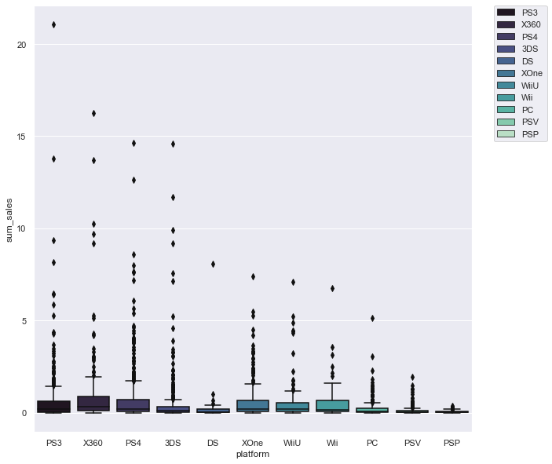

```python
# диаграмма размаха по глобальным продажам игр в разбивке по платформам
fig, ax=plt.subplots(figsize=(10,10))
sb.boxplot(data = good_data_actual, y='sum_sales', x='platform', hue= 'platform',dodge=False, palette='mako');
plt.legend( bbox_to_anchor=(1.05, 1), loc='upper left', borderaxespad=0);
```

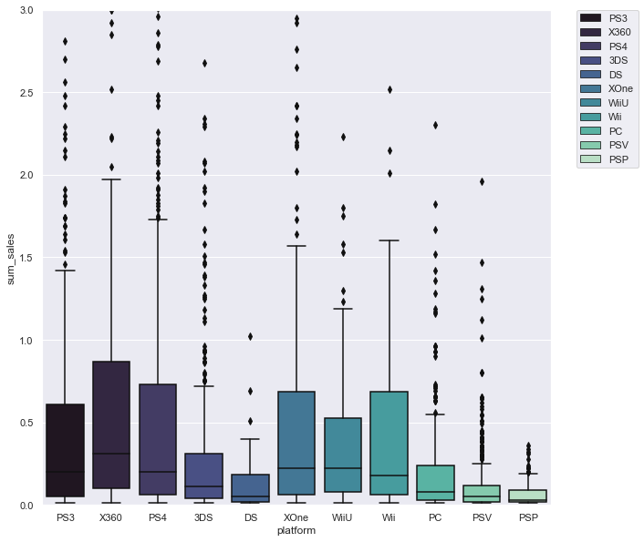

```python
# диаграмма размаха по глобальным продажам игр в разбивке по платформам: обрежем выбросы
fig, ax=plt.subplots(figsize=(10,10))
sb.boxplot(data = good_data_actual, y='sum_sales', x='platform', hue= 'platform',dodge=False,palette='mako');
plt.legend( bbox_to_anchor=(1.05, 1), loc='upper left', borderaxespad=0);
plt.ylim(0,3);
```

```python
#good_data_actual[good_data_actual['platform']=='PS4']['sum_sales'].describe()
```

```python
#good_data_actual[good_data_actual['platform']=='PS3']['sum_sales'].describe()
```

```python
#good_data_actual[good_data_actual['platform']=='PS3']
```

```python
#good_data_actual[good_data_actual['platform']=='XOne']['sum_sales'].describe()
```

```python
#good_data_actual[good_data_actual['platform']=='3DS']['sum_sales'].describe()
```

```python
#good_data_actual[good_data_actual['platform']=='WiiU']['sum_sales'].describe()
```

- Две, лидирующие по количеству проданных игр, платформы также имеют большое количесто выбросов: игры, продажи которых были нетипично велики.PS3 имеет самый высокий результат среди уникальных по продажам игр:21млн (Grand Theft Auto V).Данные результаты подтверждаются реальностью - эта игра побила сразу несколько рекордов в книге рекордов Гиннесса по количеству продаж. При этом у PS4 50% игр продается в диапазоне от 60 до 730 тыс проданных копий, в то время как у PS3 только от 50 до 610 тыс.
- Платформа XOne, занимающая только 5е место по количеству продаж, при этом имеет почти такой же МКР: от 60 до 685 тыс. Значения выбросов значительно меньше: 7,39млн самый наибольший.
- Самая продающаяся игра на платформу 3DS имеет результат в 14,6 млн копий. Размах же значительно скромнее чем у конкурентов: от 40 до 315 тыс.
- 50% игр платформы WiiU продается в диапазоне от 80 до 525 тыс.

При этом медианнное значение для всех платформ не превышает 400 тыс проданных копий и ближе к нижнему квантилю, что говорит о том, что преобладают игры с небольшими продажами и небольшим числом мегапопулярных игр. Стоит отметить, что сравнивая двух лидеров рынка: Sony и Xbox, у платформы Xbox дела обстоят лучше, их игры продаются в среднем большим тиражом ( медиана выше чем у Sony). На общий результат Sony сильно влияют узкоспецифичные-мегапопулярные игры.

### Корреляция между отзывами и продажами

```python
def relation_sum_score(platform):# функция для расчета корреляции и построения диаграммы рассеивания
    p = good_data_actual[good_data_actual['platform']==platform]
    print(p['user_score'].corr(good_data['sum_sales']).round(2))
    print(p['critic_score'].corr(good_data['sum_sales']).round(2))
    fig, (axis1,axis2) = plt.subplots(1,2, figsize=(15,6))
    p.plot(ax=axis1,kind='scatter', y='sum_sales', x='user_score', grid=True, alpha=0.6,\
           title = 'Зависимость между продажами и оценками пользователей')
    p.plot(ax=axis2,kind='scatter', y='sum_sales', x='critic_score', grid=True, alpha=0.6, \
           title = 'Зависимость между продажами и оценками критиков')
```

Рассмотрим как влияют на продажи внутри одной популярной платформы отзывы пользователей и критиков

[output not shown]

```
-0.03
0.41
```

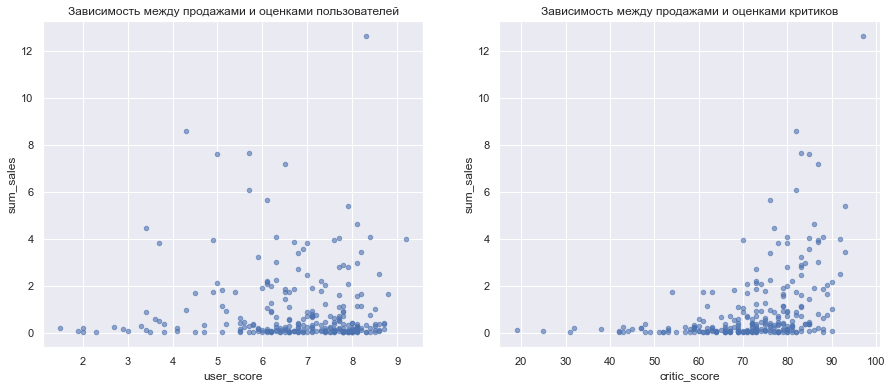

```python
relation_sum_score('PS4')
```

Корреляция между оценкой пользователей и продажами очень слабая. Между оценкой критиков и продажами-слабая

Соотнесем выводы с продажами игр на других платформах

[output not shown]

```
-0.01
0.33
```

[output not shown]

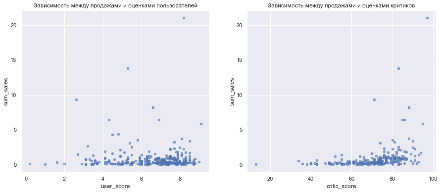

```python
relation_sum_score('PS3')
```

[output not shown]

```
-0.07
0.42
```

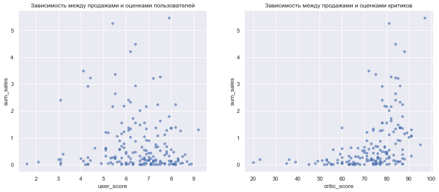

```python
relation_sum_score('XOne')
```

[output not shown]

```
0.2
0.32
```

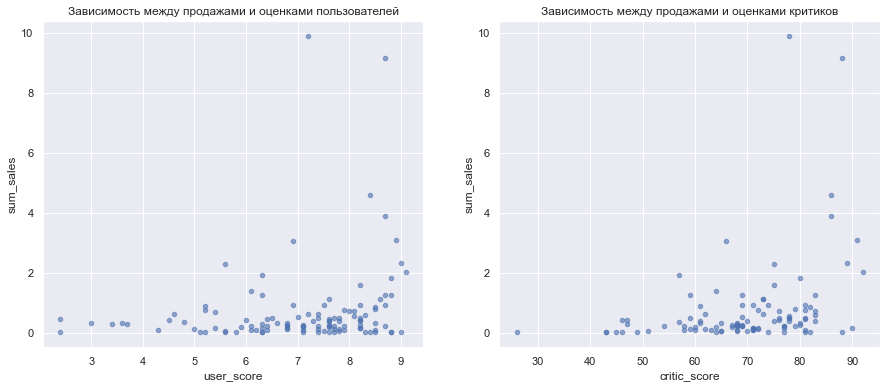

```python
relation_sum_score('3DS')
```

[output not shown]

```
0.4
0.35
```

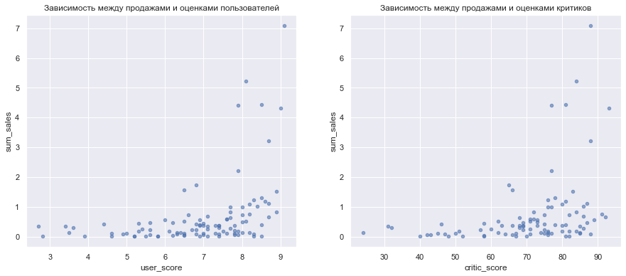

```python
relation_sum_score('WiiU')
```

На других платформах корреляции также слабые. Только на платформах 3DS и WiiU оценка пользователй больше влияет на количество проданных копий по сравнению с лидерами рынка. Влияние же оценки критиков на продажи почти одинаково на всех платформах

Из чего можно сделать вывод, что количество проданных копий не самый надежный показатель для анализа: игры могли идти в подарок за покупку чего-то более крупного, иметь очень низкую стоимость или продаваться по другой промоакции. Тогда пользователь, не смотря на мнение большинства, мог ее приобрести или согласиться скачать, так как игра досталась ему бесплатно.

При этом не стоит забывать, что корреляция Пирсона выявляет линейную зависимость. По диаграммам рассеивания можно увидеть, что зависимость экспоненциальная. Игры, продаваемые небольшим тиражом,(которых большинство,согласно выводам по диаграмме размаха), имеют низкие оценки критиков. Мегапопулярные игры имеют высокие оценки критиков. В целом зависимость от оценки критиков более ярка выражена, так как они являются инфлюенсерами и делают более структурыные обзоры, влияющие на продажи.

### Распределение игр по жанрам

```python
# сводная таблица распредления игр по жанрам
sales_by_genre = good_data_actual.pivot_table(index='genre',values ='sum_sales', aggfunc=['median', 'sum', 'count'])
sales_by_genre.columns=['median', 'sum', 'quantity']
sales_by_genre = sales_by_genre.sort_values(by='median')
sales_by_genre
```

| genre | median | sum | quantity |
| --- | --- | --- | --- |
| Adventure | 0.030 | 29.43 | 302 |
| Puzzle | 0.045 | 4.89 | 28 |
| Strategy | 0.080 | 13.34 | 71 |
| Action | 0.120 | 441.12 | 1031 |
| Misc | 0.120 | 85.04 | 192 |
| Simulation | 0.120 | 35.12 | 80 |
| Fighting | 0.130 | 44.49 | 109 |
| Racing | 0.140 | 53.50 | 115 |
| Role-Playing | 0.140 | 192.80 | 370 |
| Platform | 0.210 | 61.00 | 85 |
| Sports | 0.240 | 181.07 | 268 |
| Shooter | 0.440 | 304.73 | 235 |

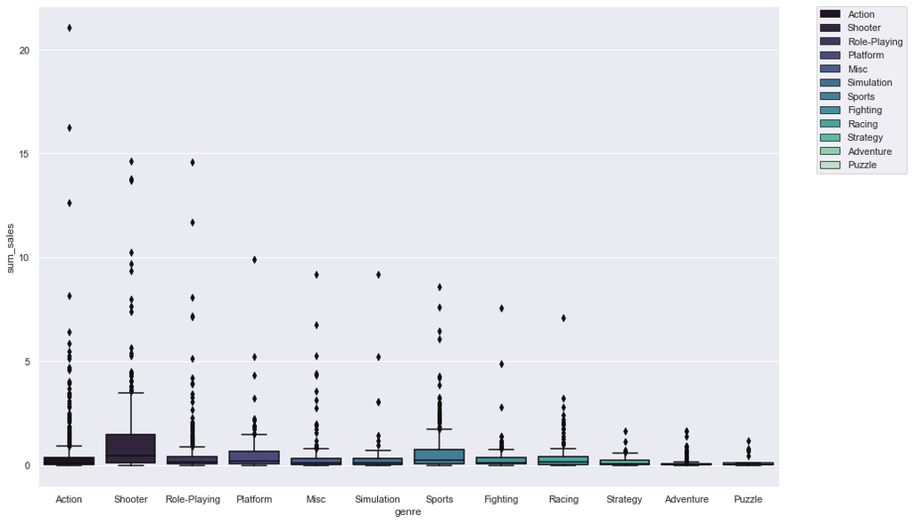

```python
# диаграмма размаха по жанрам
fig, ax=plt.subplots(figsize=(15,10))
sb.boxplot(data = good_data_actual, y='sum_sales', x='genre', hue= 'genre',dodge=False,palette='mako');
plt.legend( bbox_to_anchor=(1.05, 1), loc='upper left', borderaxespad=0);
```

Медиана отображает уровень продаж большинства игр в жанре, поэтому при оценке прибыльности лучше ориентироваться на нее. В связи с этим жанр Shooter является самым наиболее продающимся. Не смотря на то, что наибольшая сумма продаж в жанре Action, медиана которого значительно отстает от лидера. В жанре Action также наибольшее число выпущенных игр. На втором месте жанр Sports.

Диаграмма размаха также подтверждает выводы, что сумма продаж может быть наибольшой, только засчет "нетипичных" игр: жанр Action имеет наибольшие выбросы.

## Портрет пользователя

```python
regions=['na_sales', 'eu_sales','jp_sales']# регионы добавим в список для дальнейших циклов
```

```python
warnings.filterwarnings('ignore')
```

```python
# функция для определения долей продаж по платформам
def sales_platform(r):
    sales_platform = good_data_actual.pivot_table(index='platform', values=r, aggfunc='sum')\
    .sort_values(by=r, ascending=False)
    top_platform = sales_platform.head()
    others = sales_platform[r].sum() - top_platform[r].sum()
    top_platform.loc['others'] = others
    return top_platform
```

```python
# функция для определения долей продаж по жанрам
def sales_genre(r):
    sales_genre = good_data_actual.pivot_table(index='genre', values=r, aggfunc='median')\
    .sort_values(by=r, ascending=False)
    top_genre = sales_genre.head()
    others = sales_genre[r].sum() - top_genre[r].sum()
    top_genre.loc['others'] = others
    top_genre = top_genre*100
    return top_genre
```

```python
# функция для определения влияния рейтинга на прода
def sales_rating(r):
    top_rating = good_data_actual.pivot_table(index='rating', values=r, aggfunc='mean').head()*100
    return top_rating
```

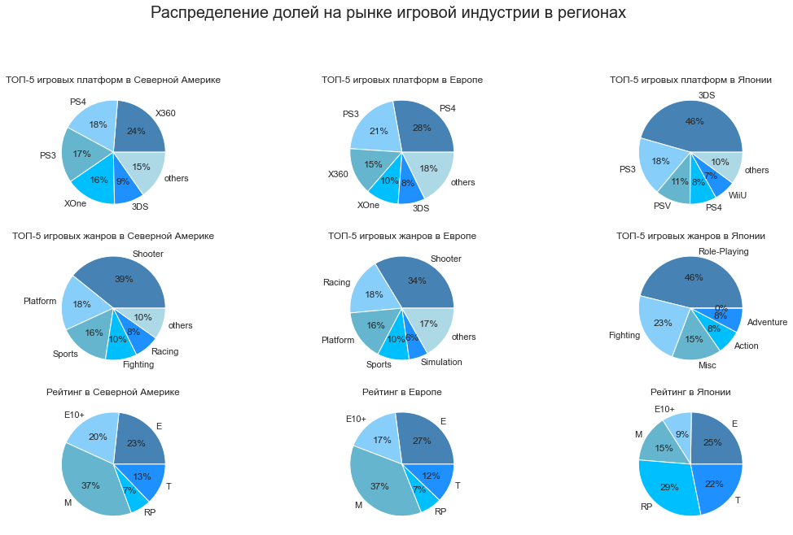

```python
# круговая диаграмма
fig, axis = plt.subplots(3,3, figsize=(18,10))
fig.suptitle('Распределение долей на рынке игровой индустрии в регионах', fontsize=20, y=1.02)

sales_platform('na_sales')['na_sales'].plot.pie(ax=axis[0,0], autopct='%1.f%%',\
title='ТОП-5 игровых платформ в Северной Америке', ylabel='', \
colors=['steelblue','lightskyblue','c','deepskyblue','dodgerblue','lightblue'])

sales_platform('eu_sales')['eu_sales'].plot.pie(ax=axis[0,1], autopct='%1.f%%', \
title='ТОП-5 игровых платформ в Европе', ylabel='', \
colors=['steelblue','lightskyblue','c','deepskyblue','dodgerblue','lightblue'])
sales_platform('jp_sales')['jp_sales'].plot.pie(ax=axis[0,2], autopct='%1.f%%',\
title='ТОП-5 игровых платформ в Японии', ylabel='', \
colors=['steelblue','lightskyblue','c','deepskyblue','dodgerblue','lightblue'])

sales_genre('na_sales')['na_sales'].plot.pie(ax=axis[1,0], autopct='%1.f%%', \
title='ТОП-5 игровых жанров в Северной Америке', ylabel='',\
colors=['steelblue','lightskyblue','c','deepskyblue','dodgerblue','lightblue'])

sales_genre('eu_sales')['eu_sales'].plot.pie(ax=axis[1,1], autopct='%1.f%%', \
title='ТОП-5 игровых жанров в Европе', ylabel='',\
colors=['steelblue','lightskyblue','c','deepskyblue','dodgerblue','lightblue'])

sales_genre('jp_sales')['jp_sales'].plot.pie(ax=axis[1,2], autopct='%1.f%%',\
title='ТОП-5 игровых жанров в Японии', ylabel='', \
colors=['steelblue','lightskyblue','c','deepskyblue','dodgerblue','lightblue']);

sales_rating('na_sales')['na_sales'].plot.pie(ax=axis[2,0], autopct='%1.f%%', \
title='Рейтинг в Северной Америке', ylabel='', \
colors=['steelblue','lightskyblue','c','deepskyblue','dodgerblue','lightblue'])

sales_rating('eu_sales')['eu_sales'].plot.pie(ax=axis[2,1], autopct='%1.f%%', \
title='Рейтинг в Европе', ylabel='', \
colors=['steelblue','lightskyblue','c','deepskyblue','dodgerblue','lightblue'])

sales_rating('jp_sales')['jp_sales'].plot.pie(ax=axis[2,2], autopct='%1.f%%', \
title='Рейтинг в Японии', ylabel='', \
colors=['steelblue','lightskyblue','c','deepskyblue','dodgerblue','lightblue']);
```

## Проверка гипотез

### Гипотеза по платформам

Нулевая и альтернативные гипотезы:

Hо: средние пользовательские рейтинги платформ Xbox One и PC равны

H1: средние пользовательские рейтинги платформ Xbox One и PC не равны

```python
# срезы по платформам
xone = good_data_actual.loc[(good_data_actual['platform']== 'XOne') & (good_data_actual['user_score']\
                                                                       .notna()), 'user_score']
pc = good_data_actual.loc[(good_data_actual['platform']== 'PC') & (good_data_actual['user_score']\
                                                                   .notna()), 'user_score']
```

```python
results = st.ttest_ind(xone,pc, equal_var=False)#  дисперсии выборок не равны
alpha = .05 # критический уровень статистической значимости - общепринятое значение
# если p-value окажется меньше него - отвергнем гипотезу

print('p-значение:', results.pvalue)

if results.pvalue < alpha:
    print("Отвергаем нулевую гипотезу")
else:
    print("Не получилось отвергнуть нулевую гипотезу")
```

```
p-значение: 0.5489537965134912
Не получилось отвергнуть нулевую гипотезу
```

Согласно расчетам отвергнуть гипотезу о том, что средние пользовательские рейтинги платформ Xbox One и PC равны нет оснований.

### Гипотеза по жанрам

Нулевая и альтернативные гипотезы:

Hо: средние пользовательские рейтинги жанров Action и Sports равны

H1: средние пользовательские рейтинги жанров Action и Sports не равны

```python
# срезы по жанрам
action = good_data_actual.loc[(good_data_actual['genre']== 'Action') & (good_data_actual['user_score']\
                                                                        .notna()), 'user_score']
sport = good_data_actual.loc[(good_data_actual['genre']== 'Sports') & (good_data_actual['user_score']\
                                                                       .notna()), 'user_score']
```

```python
results = st.ttest_ind(action,sport, equal_var=False)#  дисперсии выборок не равны
alpha = .05 # критический уровень статистической значимости- общепринятое значение
# если p-value окажется меньше него - отвергнем гипотезу

print('p-значение:', results.pvalue)

if results.pvalue < alpha:
    print("Отвергаем нулевую гипотезу")
else:
    print("Не получилось отвергнуть нулевую гипотезу")
```

```
p-значение: 4.24307776572644e-20
Отвергаем нулевую гипотезу
```

Согласно уровню статистической значимости, есть основания отвергнуть гипотезу, что средние пользовательские рейтинги жанров Action и Sports равны

## Вывод

В первоначальном датасете были обработаны пропуски, удалены дубликаты. Типы данных для столбцов Год выпуска и Оценка пользователей были изменены на целочисленный и вещественный соответственно.Пропуски в столбце Рейтинг были изменены на Rating Pending (RP) - ожидание рейтинга.

Максимальный пик по выходу игр на рынок пришелся на 2005- 2011 года. Начиная с 2012 года, среднее количество вышедших игр держится в рамках 500-600. В связи с динамичностью сферы актуальным признан период с 2012 по 2016 года.

В актуальном периоде по количеству проданных копий лидирует семейство Sony. Но продажи PS3 падают, а PS4 растут. На третьем месте по продажам платформа Х360. Ее продажи также падают, в апреле 2016 года она была снята с производства. Ее преемница XOne с растущими показателями занимает пятое место, уступая платформе 3DS. Продажи данной платформы также уменьшаются, но не с такой скоростью как продажи других платформ.На момент 2017 года ее производство и поддержка еще осуществлялись. Wii U - преемница Wii. Продажи данной платформы также уменьшаются, но не значительно, по сравнению с платформами, производство которых уже прекращено.

Платформа PS3 имеет самые большие выбросы: игры, продажи которых были нетипично велики. С точки зрения стабильности продажи PS4 гораздо привлекательнее: 50% игр продается в диапазоне от 60 до 730 тыс.  
Платформа XOne, занимающая только 5е место по количеству продаж, при этом имеет почти такой же МКР: от 60 тыс до 685 тыс. У семейства Xbox игры продаются в среднем большим тиражом ( медиана выше чем у Sony). На общий результат Sony сильно влияют узкоспецифичные-мегапопулярные игры. Самая продающаяся игра на платформу 3DS имеет результат в 14,6 млн копий. Размах же значительно скромнее чем у конкурентов: от 40 до 315 тыс. 50% игр платформы WiiU продается в диапазоне от 80 до 525 тыс.

Корреляция Пирсона между продажами и оценками пользователей и критиков слабая. Зависимость экспоненциальная. Только на платформах 3DS и WiiU оценка пользователй больше влияет на количество проданных копий по сравнению с лидерами рынка, но также довольно скромно.

Жанр Shooter является самым самым наиболее продающимся.На втором месте жанр Sports. Не смотря на то, что наибольшая сумма продаж в жанре Action, медиана значительно отстает от лидера. В жанре Action также наибольшее число выпущенных игр.

При всех вышеуказанных особенностях сферы компьютерных игр отвергнуть гипотезу о том, что средние пользовательские рейтинги платформ Xbox One и PC равны нет оснований.Основания, отвергнуть гипотезу, что средние пользовательские рейтинги жанров Action и Sports равны, достаточны.